# Water Temperature vs. Energy Demand

Cole Boyer

## Introduction

Energy can be generated in many ways. Kinetic energy, solar energy, magnetism, and using thermal power. Many power plants rely on thermal power to generate electricity. They use heat from burning fuels, which generates steam, which spins turbines that are connected to generators that produce energy. Power plants that sit along a body of water boil water to create steam. When the water is above **85 degrees Fahrenheit**, the power plant needs to operate at reduced capacity to avoid issues within the plant.

## Data Documentation

Data regarding the water temperature was taken from the **NOAA Tides and Currents** websites using an interactive and table. The dates selected (March 9th 2022 - March 8th 2023 in one hour intervals) were used because it was the last time period where data was available for a full consecutive year. Energy demand data was pulled from the **EIA** (Energy Information Administration) website, using an interactive table and using the same time frame.

**Important**

For the water temperature data, you could view the data in 6 minute intervals or in 1 hour intervals. Choosing the 6 minute intervals only allows you to see one month’s worth of data at a time, where 1 hour intervals lets you view up to a year at a time.

## Water Temperatures by Month

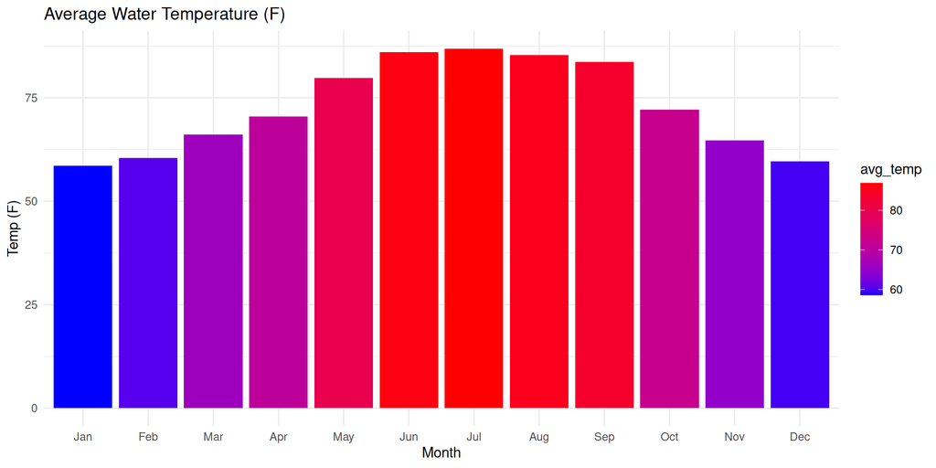

## Observations above 85 degrees Fahrenheit in Each Month

Frequency of High Water Temperature Occurrences by Month

| Month | Hours Above 85 degrees Fahrenheit |
| --- | --- |
| Jul | 662 |
| Jun | 483 |
| Aug | 432 |
| Sep | 190 |

1767 hours out of 8759 total observations were above 85 degrees Fahrenheit, which gives a proportion of **20.17%**.

## Statistical Analysis

Linear Regression Results: Water Temperature vs. Energy Demand

| term | estimate | std.error | statistic | p.value |
| --- | --- | --- | --- | --- |
| (Intercept) | 289619.595 | 30043.5466 | 9.639994 | 9.900451e-20 |
| avg_water_temp | 4876.986 | 407.3445 | 11.972630 | 4.560000e-28 |

```
The R-squared value for this model is: 0.2831
```

## Conclusion

The statistical analysis determined that the relationship between water temperature and electrical demand is significant and the power plants in and around Dauphin Island, Alabama need to prepare to operate at reduced capacity during the summer months in the next few years. The easiest way to combat this issue is to upgrade the heat exchangers. Heat exchangers are needed to cool the water so that other processes can happen.

**Warning**

Another option is to harvest cooler water from deeper in the gulf. However, in order to do this, the power plant would need to reach depths of at least 200 feet. Since plants typically sit on the shore of a body of water, this strategy is not preferred.